# Practical Machine Learning - Final Project

Nicolas A. Leali

The goal of this project is to predict the manner in which people did the exercise. This is the “classe” variable in the training set. I created this report to describe how I built the model, how I used cross validation, what I think the expected out of sample error is. There is also the script for the 20 predictions.

Data Processing and Analysis

The training and testing datasets are avaiable here:

Training dataset: https://d396qusza40orc.cloudfront.net/predmachlearn/pml-training.csv

Testing dataset: https://d396qusza40orc.cloudfront.net/predmachlearn/pml-testing.csv

Load all the librarys necesary to run the project.

```r
library(caret)
```

```r
library(ggplot2)
library(corrplot)
library(randomForest)
```

assing the data from pml-training.csv and pml-testing.csv files to the variables.

```r
training <- read.csv("pml-training.csv",na.strings = c("NA", ""))

test <- read.csv("pml-testing.csv",na.strings = c("NA", ""))
```

We search in the variables those columns that dont contibute to the analysis because they are character or non-numerical.

```r
sapply(test,class)
```

```
##                        X                user_name     raw_timestamp_part_1
##                "integer"                 "factor"                "integer"
##     raw_timestamp_part_2           cvtd_timestamp               new_window
##                "integer"                 "factor"                 "factor"
##               num_window                roll_belt               pitch_belt
##                "integer"                "numeric"                "numeric"
##                 yaw_belt         total_accel_belt       kurtosis_roll_belt
##                "numeric"                "integer"                "logical"
##      kurtosis_picth_belt        kurtosis_yaw_belt       skewness_roll_belt
##                "logical"                "logical"                "logical"
##     skewness_roll_belt.1        skewness_yaw_belt            max_roll_belt
##                "logical"                "logical"                "logical"
##           max_picth_belt             max_yaw_belt            min_roll_belt
##                "logical"                "logical"                "logical"
##           min_pitch_belt             min_yaw_belt      amplitude_roll_belt
##                "logical"                "logical"                "logical"
##     amplitude_pitch_belt       amplitude_yaw_belt     var_total_accel_belt
##                "logical"                "logical"                "logical"
##            avg_roll_belt         stddev_roll_belt            var_roll_belt
##                "logical"                "logical"                "logical"
##           avg_pitch_belt        stddev_pitch_belt           var_pitch_belt
##                "logical"                "logical"                "logical"
##             avg_yaw_belt          stddev_yaw_belt             var_yaw_belt
##                "logical"                "logical"                "logical"
##             gyros_belt_x             gyros_belt_y             gyros_belt_z
##                "numeric"                "numeric"                "numeric"
##             accel_belt_x             accel_belt_y             accel_belt_z
##                "integer"                "integer"                "integer"
##            magnet_belt_x            magnet_belt_y            magnet_belt_z
##                "integer"                "integer"                "integer"
##                 roll_arm                pitch_arm                  yaw_arm
##                "numeric"                "numeric"                "numeric"
##          total_accel_arm            var_accel_arm             avg_roll_arm
##                "integer"                "logical"                "logical"
##          stddev_roll_arm             var_roll_arm            avg_pitch_arm
##                "logical"                "logical"                "logical"
##         stddev_pitch_arm            var_pitch_arm              avg_yaw_arm
##                "logical"                "logical"                "logical"
##           stddev_yaw_arm              var_yaw_arm              gyros_arm_x
##                "logical"                "logical"                "numeric"
```

[output cut: 53 more lines]

```
##                "logical"                "integer"                "logical"
##         avg_roll_forearm      stddev_roll_forearm         var_roll_forearm
##                "logical"                "logical"                "logical"
##        avg_pitch_forearm     stddev_pitch_forearm        var_pitch_forearm
##                "logical"                "logical"                "logical"
##          avg_yaw_forearm       stddev_yaw_forearm          var_yaw_forearm
##                "logical"                "logical"                "logical"
##          gyros_forearm_x          gyros_forearm_y          gyros_forearm_z
##                "numeric"                "numeric"                "numeric"
##          accel_forearm_x          accel_forearm_y          accel_forearm_z
##                "integer"                "integer"                "integer"
##         magnet_forearm_x         magnet_forearm_y         magnet_forearm_z
##                "integer"                "integer"                "integer"
##               problem_id
##                "integer"
```

Using What we saw in the previous part we should remove some of the columns that not make sence to have with the girp function, because thay are not numeric. and create a new vector from this operation.

```r
training_aux <- training[, -(grep("timestamp|X|user_name|num_window|new_window", names(training)))]
test_aux <- test[, -(grep("timestamp|X|user_name|num_window|new_window", names(test)))]
```

Many of the columns we load have . NA`s values. We take out from the variables those data with NA's values The NA`s records make our machine learning algorithm less precise. Finally we update the vector with out any NA`s values.

```r
NAs <- apply(training_aux, 2, function(x) {
    sum(is.na(x))})

training_aux <- training_aux[, which(NAs == 0)]
test_aux <- test_aux[, which(NAs == 0)]
```

We split the data into two variables. First the training data with the 60 % and the test data with 40%.

```r
training.idx <- training_aux[createDataPartition(y = training_aux$classe, p = 0.6, list = FALSE), ]
test.idx <- training_aux[-createDataPartition(y = training_aux$classe, p = 0.6, list = FALSE), ]
```

We take a look how our variables shrink, with out the NA`s values.

```r
dim(training.idx)
```

```
## [1] 11776    53
```

```r
head(training.idx)
```

```
##    roll_belt pitch_belt yaw_belt total_accel_belt gyros_belt_x
## 2       1.41       8.07    -94.4                3         0.02
## 3       1.42       8.07    -94.4                3         0.00
## 4       1.48       8.05    -94.4                3         0.02
## 9       1.43       8.16    -94.4                3         0.02
## 11      1.45       8.18    -94.4                3         0.03
## 20      1.59       8.07    -94.4                3         0.02
##    gyros_belt_y gyros_belt_z accel_belt_x accel_belt_y accel_belt_z
## 2             0        -0.02          -22            4           22
## 3             0        -0.02          -20            5           23
## 4             0        -0.03          -22            3           21
## 9             0        -0.02          -20            2           24
## 11            0        -0.02          -21            2           23
## 20            0        -0.02          -22            5           22
##    magnet_belt_x magnet_belt_y magnet_belt_z roll_arm pitch_arm yaw_arm
```

[output cut: 69 more lines]

this graph is usefull to look at the correlation with some variables to each others. Note that the dark blue indicated strong correlation and red negative correlation. Our dataset is 11776 X 53 and one of those is Classe, the variable we want to predict. This graph shows us nice information to implement a Random Forest Study.

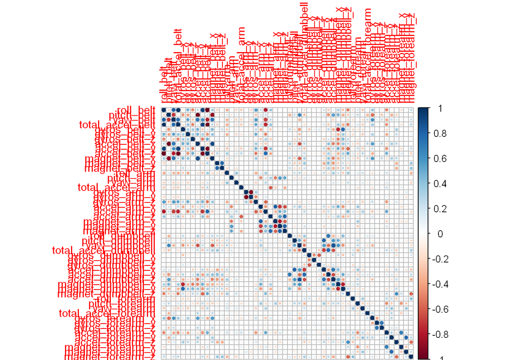

```r
Graph <- training.idx

NAs <- apply(training.idx, 2, function(x) {
    sum(is.na(x))
})
Graph<- training.idx[, which(NAs == 0)]



CorrePlot = cor( Graph[,-c(grep("timestamp|X|user_name|num_window|new_window",names(Graph)), length(Graph))])
corrplot(CorrePlot, method="circle",tl.cex=0.9)
```

At this point we create our model using Random Forest and the set of data originally given but reduced. We train our model over the dataset using the “boot” method inside trainControl.

```r
set.seed(4242)

MyModel.Forest<- train(training.idx$classe ~ ., data = training.idx, method = "rf",
    prof = TRUE, trControl = trainControl(method = "boot", number = 5, allowParallel = TRUE))

summary(MyModel.Forest)
```

```
##                 Length Class      Mode
## call                5  -none-     call
## type                1  -none-     character
## predicted       11776  factor     numeric
## err.rate         3000  -none-     numeric
## confusion          30  -none-     numeric
## votes           58880  matrix     numeric
## oob.times       11776  -none-     numeric
## classes             5  -none-     character
## importance         52  -none-     numeric
## importanceSD        0  -none-     NULL
## localImportance     0  -none-     NULL
## proximity           0  -none-     NULL
## ntree               1  -none-     numeric
## mtry                1  -none-     numeric
## forest             14  -none-     list
## y               11776  factor     numeric
## test                0  -none-     NULL
## inbag               0  -none-     NULL
## xNames             52  -none-     character
## problemType         1  -none-     character
## tuneValue           1  data.frame list
## obsLevels           5  -none-     character
```

```r
MyModel.Forest
```

[output not shown]

```r
MyModel.Forest.Final<- MyModel.Forest$results
round(max(MyModel.Forest.Final$Accuracy), 3) * 100
```

```
## [1] 98.5
```

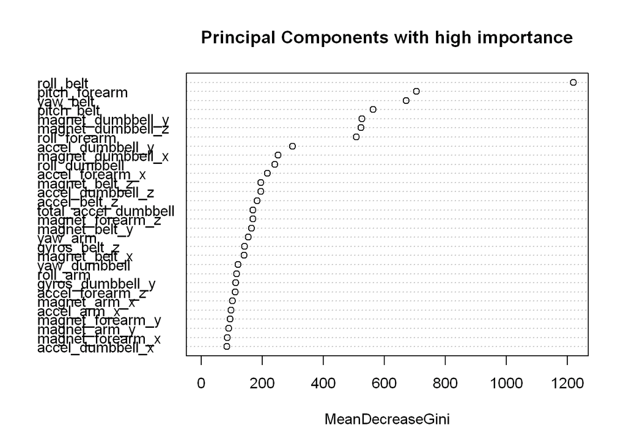

```r
varImpPlot(MyModel.Forest$finalModel,
            main = "Principal Components with high importance")
```

## The cross validation study of our model.

```r
test.idx$predRight <- (predict(MyModel.Forest, test.idx))== test.idx$classe
table(predict(MyModel.Forest, test.idx), test.idx$classe)
```

```
##
##        A    B    C    D    E
##   A 2231   11    0    0    0
##   B    1 1505    2    0    0
##   C    0    1 1360    6    1
##   D    0    1    6 1279    0
##   E    0    0    0    1 1441
```

```r
CrossValidated<- postResample((predict(MyModel.Forest, test.idx)), test.idx$classe)
CrossValidated
```

```
## Accuracy    Kappa
##   0.9962   0.9952
```

We got a nice high level of accuracy.

# We try out with the ConfussionMatrix

```r
set.seed(4242)
CrossValidatedError <- confusionMatrix((predict(MyModel.Forest, test.idx)), test.idx$classe)
CrossValidatedError
```

```
## Confusion Matrix and Statistics
##
##           Reference
## Prediction    A    B    C    D    E
##          A 2231   11    0    0    0
##          B    1 1505    2    0    0
##          C    0    1 1360    6    1
##          D    0    1    6 1279    0
##          E    0    0    0    1 1441
##
## Overall Statistics
##
##                Accuracy : 0.996
##                  95% CI : (0.995, 0.997)
##     No Information Rate : 0.284
##     P-Value [Acc > NIR] : <2e-16
##
##                   Kappa : 0.995
##  Mcnemar's Test P-Value : NA
##
## Statistics by Class:
##
##                      Class: A Class: B Class: C Class: D Class: E
## Sensitivity             1.000    0.991    0.994    0.995    0.999
## Specificity             0.998    1.000    0.999    0.999    1.000
## Pos Pred Value          0.995    0.998    0.994    0.995    0.999
## Neg Pred Value          1.000    0.998    0.999    0.999    1.000
## Prevalence              0.284    0.193    0.174    0.164    0.184
## Detection Rate          0.284    0.192    0.173    0.163    0.184
## Detection Prevalence    0.286    0.192    0.174    0.164    0.184
## Balanced Accuracy       0.999    0.995    0.996    0.997    1.000
```

```r
postResample((predict(MyModel.Forest, test.idx)), test.idx$classe)[[1]]
```

```
## [1] 0.9962
```

```r
1- postResample((predict(MyModel.Forest, test.idx)), test.idx$classe)[[1]]
```

```
## [1] 0.003824
```

we can see that our calculus were very close with the result of the matrix. The accurance is 99.6%

# The 20 cases to predict

```r
Model.Prediction <- predict(MyModel.Forest, test)
Model.Prediction
```

```
##  [1] B A B A A E D B A A B C B A E E A B B B
## Levels: A B C D E
```